# Többváltozós adatelemzés Pet Project

Dittrich Levente, Szabó Zente

2023-12-03

```r
library(tidyverse)
library(knitr)
library(kableExtra)
library(ppcor)
library(corrplot)
library(glmnet)
library(fastDummies)
library(tidymodels)
library(caTools)
library(earth)
library(plotmo)
library(caret)
library(factoextra)
```

```r
df = read.csv("data/train.csv")
# test = read.csv("data/test.csv")
```

# Adatok bemutatása

Az adatokat a Kaggle oldaláról szereztük, egy kezdőknek szóló machine learning verseny datasetje, ahol [amerikai ingatlanok](https://www.kaggle.com/competitions/house-prices-advanced-regression-techniques) árát kell megbecsülni. Az adatok között volt test és train set, amik abban térnek el egymástól, hogy a test set megfigyelései nem tartalmazzák az eladási árat. Ez érthető, hiszen a verseny lényege, hogy beküldjük eredményeinket.

Mivel valahogy a túlillesztést el szeretnénk kerülni, ezért a train setünk tovább bontjuk 80-20%-ra, hogy abból legyen train és test datasetünk.

Érdemes lehet először az adatsor felső 5 sorát szemügyre venni.

```r
head(df) %>%
  kbl() %>%
  kable_styling(bootstrap_options = c("striped", "hover", "condensed", "responsive")) %>%
  kable_paper() %>%
  scroll_box(width = "100%")
```

| Id | MSSubClass | MSZoning | LotFrontage | LotArea | Street | Alley | LotShape | LandContour | Utilities | LotConfig | LandSlope | Neighborhood | Condition1 | Condition2 | BldgType | HouseStyle | OverallQual | OverallCond | YearBuilt | YearRemodAdd | RoofStyle | RoofMatl | Exterior1st | Exterior2nd | MasVnrType | MasVnrArea | ExterQual | ExterCond | Foundation | … |
| --- | --- | --- | --- | --- | --- | --- | --- | --- | --- | --- | --- | --- | --- | --- | --- | --- | --- | --- | --- | --- | --- | --- | --- | --- | --- | --- | --- | --- | --- | --- |
| 1 | 60 | RL | 65 | 8450 | Pave | NA | Reg | Lvl | AllPub | Inside | Gtl | CollgCr | Norm | Norm | 1Fam | 2Story | 7 | 5 | 2003 | 2003 | Gable | CompShg | VinylSd | VinylSd | BrkFace | 196 | Gd | TA | PConc | … |
| 2 | 20 | RL | 80 | 9600 | Pave | NA | Reg | Lvl | AllPub | FR2 | Gtl | Veenker | Feedr | Norm | 1Fam | 1Story | 6 | 8 | 1976 | 1976 | Gable | CompShg | MetalSd | MetalSd | None | 0 | TA | TA | CBlock | … |
| 3 | 60 | RL | 68 | 11250 | Pave | NA | IR1 | Lvl | AllPub | Inside | Gtl | CollgCr | Norm | Norm | 1Fam | 2Story | 7 | 5 | 2001 | 2002 | Gable | CompShg | VinylSd | VinylSd | BrkFace | 162 | Gd | TA | PConc | … |
| 4 | 70 | RL | 60 | 9550 | Pave | NA | IR1 | Lvl | AllPub | Corner | Gtl | Crawfor | Norm | Norm | 1Fam | 2Story | 7 | 5 | 1915 | 1970 | Gable | CompShg | Wd Sdng | Wd Shng | None | 0 | TA | TA | BrkTil | … |
| 5 | 60 | RL | 84 | 14260 | Pave | NA | IR1 | Lvl | AllPub | FR2 | Gtl | NoRidge | Norm | Norm | 1Fam | 2Story | 8 | 5 | 2000 | 2000 | Gable | CompShg | VinylSd | VinylSd | BrkFace | 350 | Gd | TA | PConc | … |
| 6 | 50 | RL | 85 | 14115 | Pave | NA | IR1 | Lvl | AllPub | Inside | Gtl | Mitchel | Norm | Norm | 1Fam | 1.5Fin | 5 | 5 | 1993 | 1995 | Gable | CompShg | VinylSd | VinylSd | None | 0 | TA | TA | Wood | … |

Mivel a lakásárakkal együtt 80 változónk van, ezért egyenként nem tudunk elmagyarázni minden változót, azonban a data_description.txt nevű fájlban minden változó ki van fejtve. A szükséges változókat azonban ismertetni fogjuk.

```r
df[is.na(df)] = 0
```

A leíró statisztika előtt a minőségi változókat *factor*-rá kell alakítani, hogy ennek mulasztásából következő hibákat elkerüljük.

```r
df[,c(2:3,6:19,22:26,28:34,36,40:43,54,56,58,59,61,64:66,73:75,77:80)] = lapply(df[,c(2:3,6:19,22:26,28:34,36,40:43,54,56,58,59,61,64:66,73:75,77:80)], factor)
```

## Leíró statisztika

Leíró statisztikai mutatók a numerikus változókra:

```r
psych::describe(df, omit = T) %>%
  kbl() %>%
  kable_styling(bootstrap_options = c("striped", "hover", "condensed", "responsive")) %>%
  kable_paper() %>%
  scroll_box(width = "100%", height = "300px")
```

|  | vars | n | mean | sd | median | trimmed | mad | min | max | range | skew | kurtosis | se |
| --- | --- | --- | --- | --- | --- | --- | --- | --- | --- | --- | --- | --- | --- |
| Id | 1 | 1460 | 7.305000e+02 | 4.216100e+02 | 730.5 | 7.305000e+02 | 541.1490 | 1 | 1460 | 1459 | 0.0000000 | -1.2024660 | 11.0340382 |
| LotFrontage | 4 | 1460 | 5.762329e+01 | 3.466430e+01 | 63.0 | 5.793921e+01 | 25.2042 | 0 | 313 | 313 | 0.2672723 | 3.5851881 | 0.9072063 |
| LotArea | 5 | 1460 | 1.051683e+04 | 9.981265e+03 | 9478.5 | 9.563284e+03 | 2962.2348 | 1300 | 215245 | 213945 | 12.1826150 | 202.2623223 | 261.2216422 |
| YearBuilt | 20 | 1460 | 1.971268e+03 | 3.020290e+01 | 1973.0 | 1.974127e+03 | 37.0650 | 1872 | 2010 | 138 | -0.6122012 | -0.4456575 | 0.7904461 |
| YearRemodAdd | 21 | 1460 | 1.984866e+03 | 2.064541e+01 | 1994.0 | 1.986369e+03 | 19.2738 | 1950 | 2010 | 60 | -0.5025278 | -1.2743655 | 0.5403150 |
| MasVnrArea | 27 | 1460 | 1.031171e+02 | 1.807314e+02 | 0.0 | 6.254110e+01 | 0.0000 | 0 | 1600 | 1600 | 2.6721170 | 10.0846692 | 4.7299562 |
| BsmtFinSF1 | 35 | 1460 | 4.436397e+02 | 4.560981e+02 | 383.5 | 3.860762e+02 | 568.5771 | 0 | 5644 | 5644 | 1.6820413 | 11.0568141 | 11.9366326 |
| BsmtFinSF2 | 37 | 1460 | 4.654932e+01 | 1.613193e+02 | 0.0 | 1.382705e+00 | 0.0000 | 0 | 1474 | 1474 | 4.2465214 | 20.0088641 | 4.2219183 |
| BsmtUnfSF | 38 | 1460 | 5.672404e+02 | 4.418670e+02 | 477.5 | 5.192885e+02 | 426.9888 | 0 | 2336 | 2336 | 0.9183784 | 0.4645113 | 11.5641868 |
| TotalBsmtSF | 39 | 1460 | 1.057429e+03 | 4.387053e+02 | 991.5 | 1.036695e+03 | 347.6697 | 0 | 6110 | 6110 | 1.5211239 | 13.1788560 | 11.4814431 |
| X1stFlrSF | 44 | 1460 | 1.162627e+03 | 3.865877e+02 | 1087.0 | 1.129991e+03 | 347.6697 | 334 | 4692 | 4358 | 1.3739290 | 5.7101321 | 10.1174635 |
| X2ndFlrSF | 45 | 1460 | 3.469925e+02 | 4.365284e+02 | 0.0 | 2.853639e+02 | 0.0000 | 0 | 2065 | 2065 | 0.8113600 | -0.5590240 | 11.4244713 |
| LowQualFinSF | 46 | 1460 | 5.844520e+00 | 4.862308e+01 | 0.0 | 0.000000e+00 | 0.0000 | 0 | 572 | 572 | 8.9928333 | 82.8282385 | 1.2725242 |
| GrLivArea | 47 | 1460 | 1.515464e+03 | 5.254804e+02 | 1464.0 | 1.467670e+03 | 483.3276 | 334 | 5642 | 5308 | 1.3637536 | 4.8634828 | 13.7524502 |
| BsmtFullBath | 48 | 1460 | 4.253425e-01 | 5.189106e-01 | 0.0 | 3.921233e-01 | 0.0000 | 0 | 3 | 3 | 0.5948424 | -0.8432916 | 0.0135805 |
| BsmtHalfBath | 49 | 1460 | 5.753420e-02 | 2.387526e-01 | 0.0 | 0.000000e+00 | 0.0000 | 0 | 2 | 2 | 4.0949749 | 16.3099569 | 0.0062484 |
| FullBath | 50 | 1460 | 1.565068e+00 | 5.509158e-01 | 2.0 | 1.560788e+00 | 0.0000 | 0 | 3 | 3 | 0.0364865 | -0.8611503 | 0.0144181 |
| HalfBath | 51 | 1460 | 3.828767e-01 | 5.028854e-01 | 0.0 | 3.433219e-01 | 0.0000 | 0 | 2 | 2 | 0.6745093 | -1.0799824 | 0.0131611 |
| BedroomAbvGr | 52 | 1460 | 2.866438e+00 | 8.157780e-01 | 3.0 | 2.852740e+00 | 0.0000 | 0 | 8 | 8 | 0.2113551 | 2.2119881 | 0.0213499 |
| KitchenAbvGr | 53 | 1460 | 1.046575e+00 | 2.203382e-01 | 1.0 | 1.000000e+00 | 0.0000 | 0 | 3 | 3 | 4.4791783 | 21.4211386 | 0.0057665 |
| TotRmsAbvGrd | 55 | 1460 | 6.517808e+00 | 1.625393e+00 | 6.0 | 6.408390e+00 | 1.4826 | 2 | 14 | 12 | 0.6749517 | 0.8683368 | 0.0425385 |
| Fireplaces | 57 | 1460 | 6.130137e-01 | 6.446664e-01 | 1.0 | 5.342466e-01 | 1.4826 | 0 | 3 | 3 | 0.6482311 | -0.2244068 | 0.0168717 |
| GarageYrBlt | 60 | 1460 | 1.868740e+03 | 4.536973e+02 | 1977.0 | 1.978145e+03 | 32.6172 | 0 | 2010 | 2010 | -3.8615534 | 12.9725904 | 11.8738009 |
| GarageCars | 62 | 1460 | 1.767123e+00 | 7.473150e-01 | 2.0 | 1.773973e+00 | 0.0000 | 0 | 4 | 4 | -0.3418454 | 0.2117307 | 0.0195581 |
| GarageArea | 63 | 1460 | 4.729801e+02 | 2.138048e+02 | 480.0 | 4.698082e+02 | 177.9120 | 0 | 1418 | 1418 | 0.1796113 | 0.9044687 | 5.5955284 |
| WoodDeckSF | 67 | 1460 | 9.424452e+01 | 1.253388e+02 | 0.0 | 7.175771e+01 | 0.0000 | 0 | 857 | 857 | 1.5382100 | 2.9704171 | 3.2802662 |
| OpenPorchSF | 68 | 1460 | 4.666027e+01 | 6.625603e+01 | 25.0 | 3.323288e+01 | 37.0650 | 0 | 547 | 547 | 2.3594857 | 8.4414910 | 1.7339995 |
| EnclosedPorch | 69 | 1460 | 2.195411e+01 | 6.111915e+01 | 0.0 | 3.866438e+00 | 0.0000 | 0 | 552 | 552 | 3.0835258 | 10.3726341 | 1.5995612 |
| X3SsnPorch | 70 | 1460 | 3.409589e+00 | 2.931733e+01 | 0.0 | 0.000000e+00 | 0.0000 | 0 | 508 | 508 | 10.2831784 | 123.0623116 | 0.7672696 |
| ScreenPorch | 71 | 1460 | 1.506096e+01 | 5.575742e+01 | 0.0 | 0.000000e+00 | 0.0000 | 0 | 480 | 480 | 4.1137473 | 18.3426076 | 1.4592383 |
| PoolArea | 72 | 1460 | 2.758904e+00 | 4.017731e+01 | 0.0 | 0.000000e+00 | 0.0000 | 0 | 738 | 738 | 14.7979183 | 222.1917078 | 1.0514882 |
| MiscVal | 76 | 1460 | 4.348904e+01 | 4.961230e+02 | 0.0 | 0.000000e+00 | 0.0000 | 0 | 15500 | 15500 | 24.4265224 | 697.6400721 | 12.9841330 |
| SalePrice | 81 | 1460 | 1.809212e+05 | 7.944250e+04 | 163000.0 | 1.707833e+05 | 56338.8000 | 34900 | 755000 | 720100 | 1.8790086 | 6.4967893 | 2079.1053240 |

Mivel temérdek numerikus változónak van, ezért mindet nem szándékozzuk elemezni a leíró statisztikai mutatószámait alapul véve, azonban az eredményváltozó esetében ezt szükségesnek tartjuk.

A SalePrice, azaz az eladási ár dollárban van megadva, lévén az USA-ban vannak ezek az ingatlanok. Az átlagos igatlanár $180,921, a medián $163,000. Ez utalhat arra, hogy az eloszlás jobbra elnyúló lehet, mivel a középérték az átlag alatt van. A jobbra elnyúló eloszlás a közgazdasági adatok esetében gyakori jelenség, rendszeresen szokták kezelni logaritmizálással. A szórás 79,442.5 USD, a MAD $56,338.8, vagyis a mediántól vett adatok abszolút eltérésének mediánja. Az $\alpha_{3}$ és $\alpha_{4}$ értékei 1-nél és 3-nál nagyobbak, ami azt jelenti, hogy az eloszlás jobbra elnyúló és a normális eloszlásnál csúcsosabb.

## Adatvizualizáció

Mindenek előtt az előző pontban tárgyalt eladási ár hisztogramját vennénk szemügyre.

### Hisztogramok

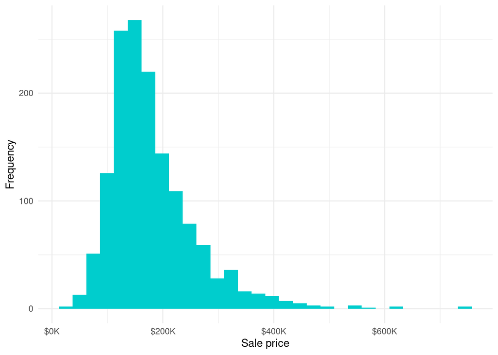

```r
ggplot(df, aes(SalePrice)) +
  geom_histogram(fill = "cyan3") +
  theme_minimal()+
  labs(x = "Sale price", y = "Frequency")+
  scale_x_continuous(labels = scales::dollar_format(scale = .001, suffix = "K"))
```

Látszik az, amit a leíró statisztikai mutatókból következtetni lehetett: jobbra elnyúló, csúcsos eloszlás. Érdemes lenne a természetes logaritmusát venni a leendő eredményváltozónknak és az eloszlását is szemügyre venni.

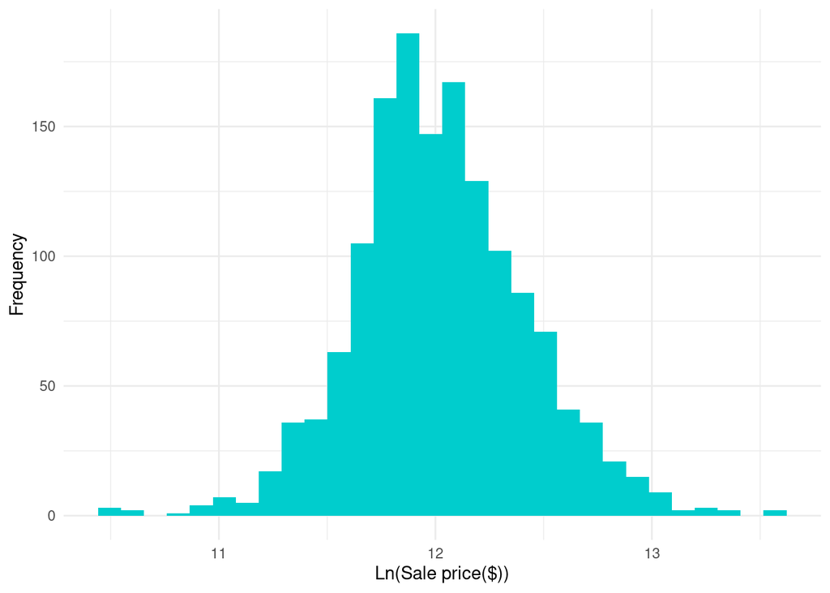

```r
ggplot(df, aes(log(SalePrice))) +
  geom_histogram(fill = "cyan3") +
  theme_minimal()+
  labs(x = "Ln(Sale price($))", y = "Frequency")
```

Ez az eloszlás már sokkal jobban hasonlít a normális eloszláshoz, mint a logaritmizálás előtti.

### Épület típusok

Az adatok között többféle épülettípus is van, ezek a következők:

| Rövidítés | Teljes név, angolul | Fordítás |
| --- | --- | --- |
| RM | Residential Medium Density | Közepes sűrűségű lakóterület |
| RL | Residential Low Density | Alacsony sűrűségű lakóterület |
| RH | Residential High Density | Nagy sűrűségű lakóterület |
| FV | Floating Village Residential | Úszófalu lakóövezet |
| C | Commercial | Kereskedelmi |

Ábrázolva, hogy melyik típusból mennyi került eladásra a következőt látjuk:

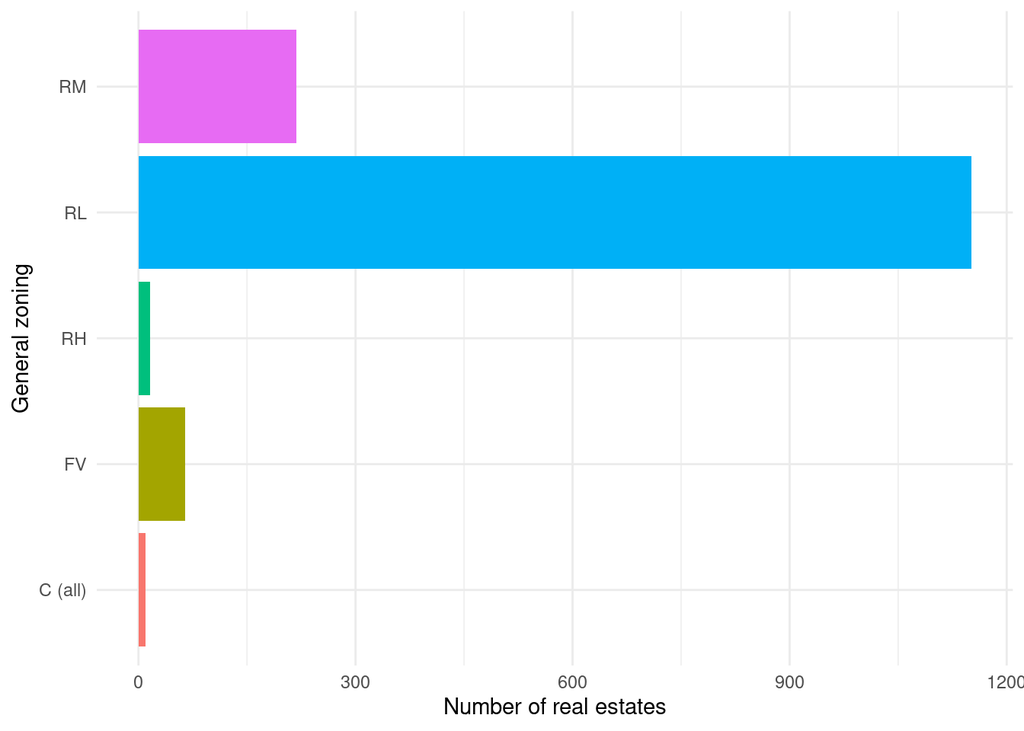

```r
ggplot(df,aes(y = MSZoning, fill = MSZoning))+
  geom_bar(position = "dodge", stat = "count")+
  theme_minimal()+
  theme(legend.position = "none")+
  labs(x = "Number of real estates", y = "General zoning")
```

Az ingatlanok elhelyezkedése is kihatással lehet az árukra, ennek kiderítésére az egyes *Neighborhood*-okban eladott házak dobozábráit elkészítettük:

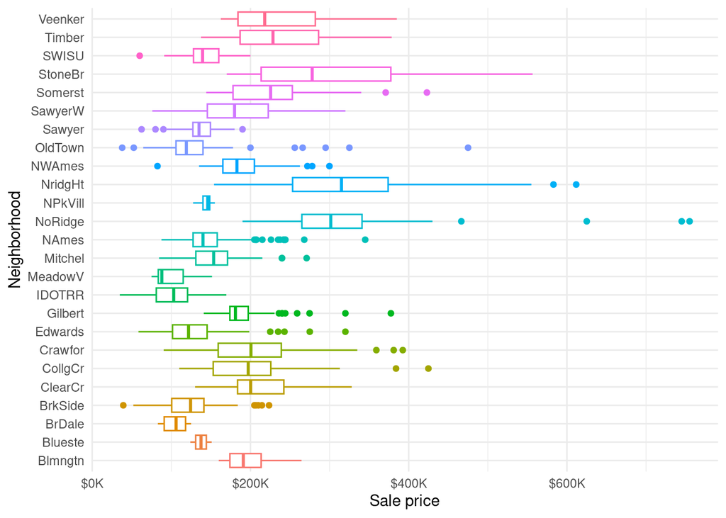

```r
ggplot(df, aes(x = SalePrice, y = Neighborhood, col = Neighborhood))+
  geom_boxplot()+
  theme_minimal()+
  theme(legend.position = "none")+
  labs(y = "Neighborhood", x = "Sale price")+
  scale_x_continuous(labels = scales::dollar_format(scale = .001, suffix = "K"))
```

Láthatóan vannak olyan környékek, amik árai merőben eltérnek másokétól.

### Eladások havonta

Az adataink 2006 és 2010 közötti időszakból vannak, azon belül is hónap pontossággal tudjuk az eladások dátumát.

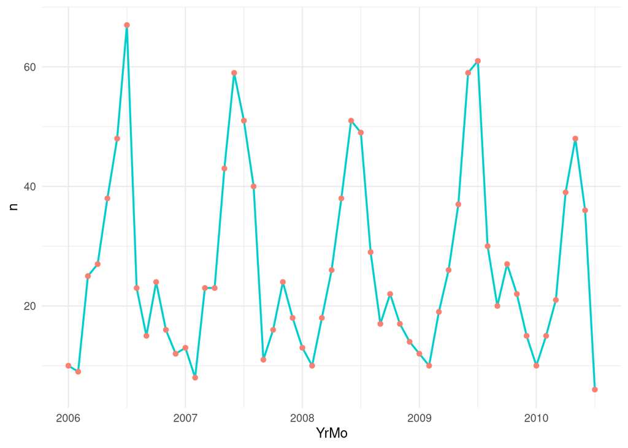

```r
ts = df %>%
  mutate(YrMo = paste0(YrSold, "-", MoSold)) %>%
  count(YrMo)

ts$YrMo = zoo::as.yearmon(ts$YrMo)

ggplot(ts,aes(x = YrMo, y = n))+
  geom_line(color = "cyan3", linewidth = .75)+
  geom_point(color = "salmon")+
  theme_minimal()
```

Látható, hogy minden évben kiugróak a május és július közötti lakásvásárlások.

## Korreláció

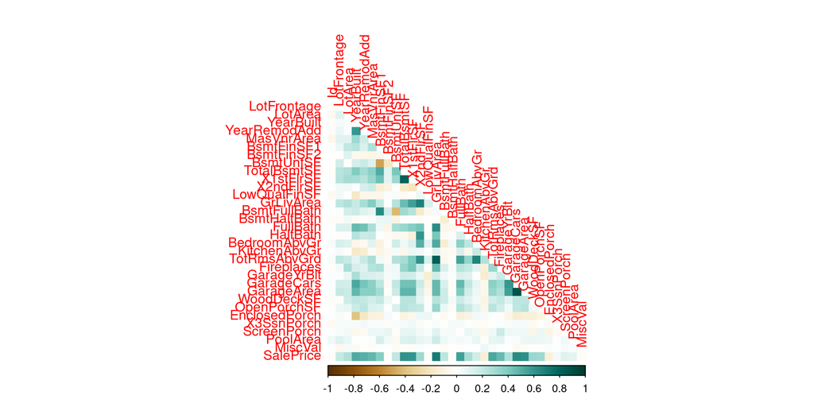

```r
corrplot(cor(select_if(df, is.numeric)), method = "color", col = COL2("BrBG"), diag = F, type = "lower")
```

# Modellek

Az adatokat tehát ketté bontjuk 80-20%-ban train és test dataset-ekre.

```r
set.seed(2023)

sample = sample.split(df$SalePrice, SplitRatio = .8)
train = subset(df, sample == T)
test = subset(df, sample == F)
```

## Klaszterezés

```r
n_df = scale((select_if(df[,-81], is.numeric)))
n_df = n_df[!rowSums(is.na(n_df)),]
```

### Hierarchikus klaszterezés

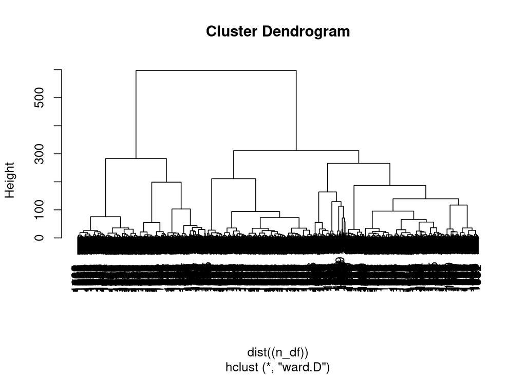

```r
hier = hclust(dist((n_df)), method = "ward.D")
plot(hier)
```

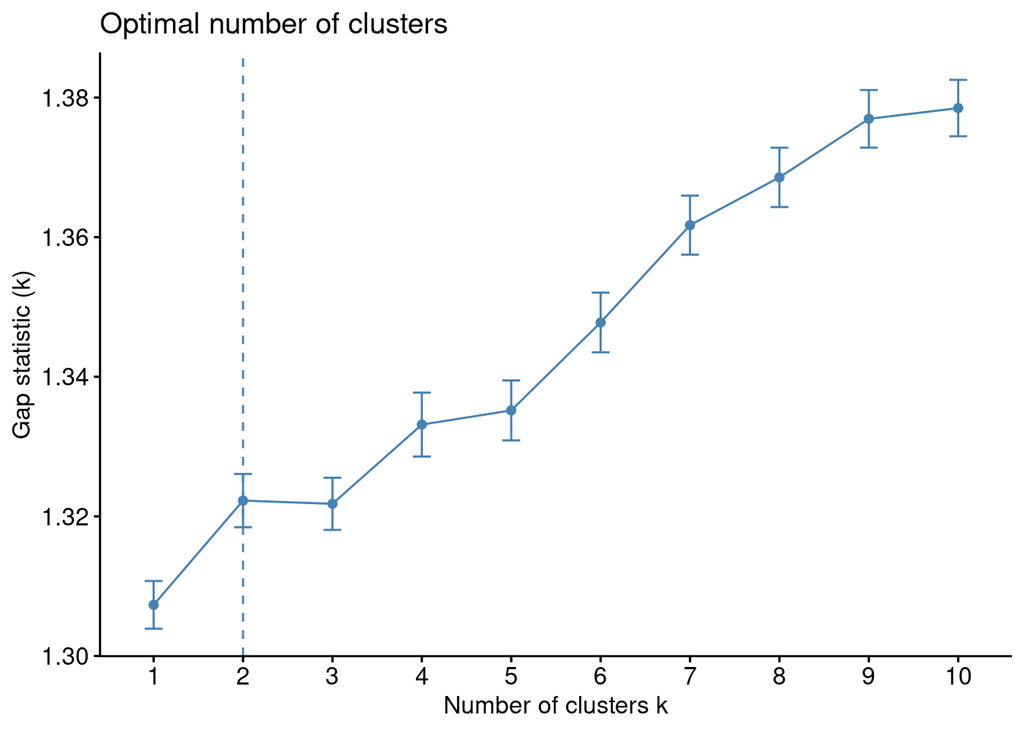

```r
fviz_nbclust(n_df, FUNcluster = hcut, method = "gap_stat")
```

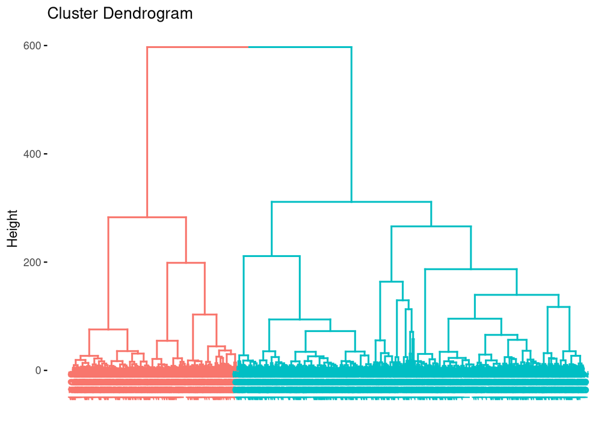

```r
fviz_dend(hier, k = 2)
```

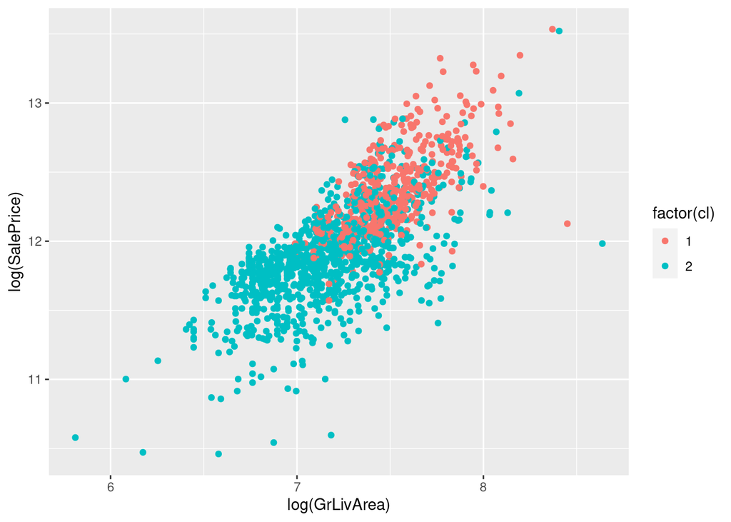

```r
df_hc = as.data.frame(df) %>%
  mutate(cl = cutree(hier, k = 2))

ggplot(df_hc, aes(log(GrLivArea), log(SalePrice), color = factor(cl)))+
  geom_point()
```

A Gap-Statisztika segítségével meghatároztuk az optimális klaszterek számát, majd ezt endogramon megjelenítettük. A fák ágai nagyon hamar rendkívül szerteágazóak lesznek a sok változó miatt. A pontdiagramon (log alapterült - log eladási ár) látszik azonban, hogy a csoportokon belül még jelentős az eltérés, a klaszterekben lévő pontok elég távol helyezkednek el egymástól (nem elég homogén a két csoport).

### K-középpontú klaszterezés

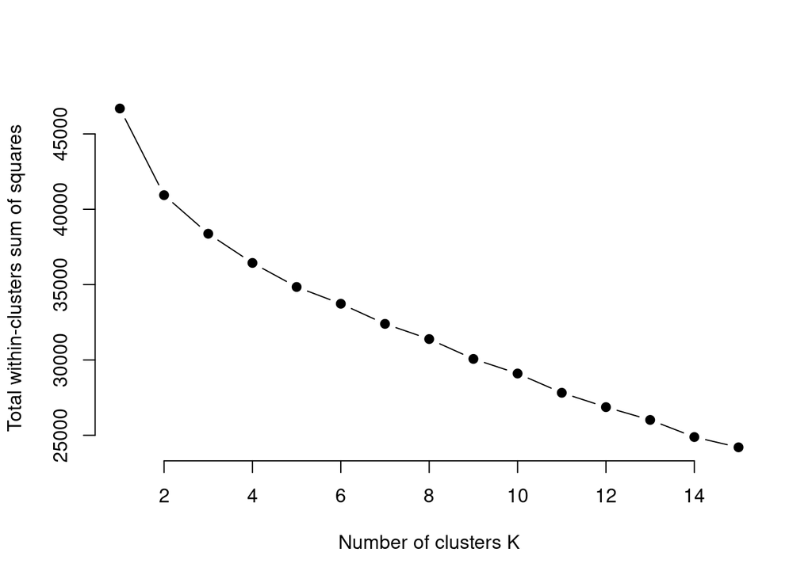

```r
wss = sapply(1:15, function(x){kmeans(n_df, x, nstart = 100, iter.max = 100)$tot.withinss})

plot(1:15, wss,
     type = "b", pch = 19, frame = F,
     xlab = "Number of clusters K",
     ylab = "Total within-clusters sum of squares")
```

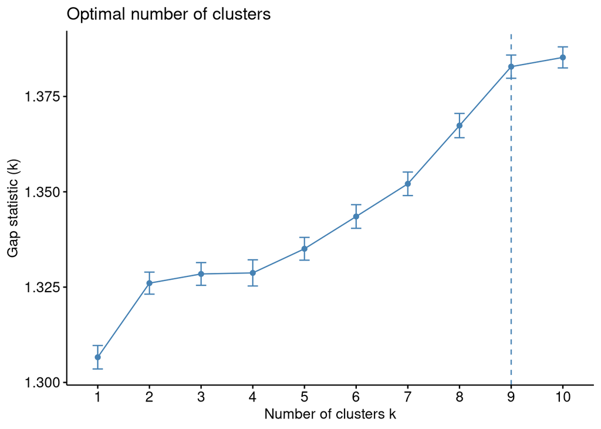

```r
fviz_nbclust(n_df, FUNcluster = kmeans, method = "gap_stat")
```

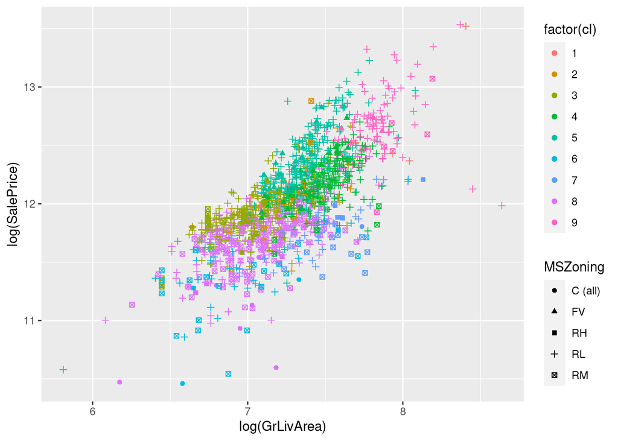

```r
km = kmeans(n_df, 9, nstart = 100, iter.max = 100)

df_km = as.data.frame(df) %>%
  mutate(cl = km$cluster)

ggplot(df_km, aes(log(GrLivArea), log(SalePrice), color = factor(cl), shape = MSZoning))+
  geom_point()
```

A k-központú klaszterezéssel a homogenitást szerettük volna növelni (csökkenteni a klasztereken belüli különbségeket), erre a módszerre a Gap-Statisztika 9 klasztert adott válaszként. A pontdiagramon is látszik hogy a csoporton belüli távolságok csökkentek, viszont a csoportok közti távolságokat továbbra is alacsonyak, tehát nem teljesen ideális a klaszterezés.

## Főkomponens-elemzés

### Sajátértékek

```r
eigen_df <- eigen(cor(select_if(df, is.numeric)))
eigen_df$values
```

```
##  [1]  6.942686e+00  3.112559e+00  2.121463e+00  1.917386e+00  1.360938e+00
##  [6]  1.245394e+00  1.143603e+00  1.095362e+00  1.090238e+00  1.034848e+00
## [11]  1.017930e+00  1.010119e+00  9.496145e-01  9.035207e-01  8.845203e-01
## [16]  8.344641e-01  8.188000e-01  7.465548e-01  6.899252e-01  6.379501e-01
## [21]  6.213611e-01  5.755787e-01  3.940505e-01  3.877033e-01  3.531986e-01
## [26]  3.099350e-01  2.152447e-01  1.939973e-01  1.582698e-01  1.342196e-01
## [31]  9.856563e-02  1.493929e-16 -3.831401e-16
```

```r
sum(eigen_df$values)
```

```
## [1] 33
```

### Kaiser-kritérium vizsgálatához:

Numerikus adatok kiválasztása

```r
df_num <- select_if(df, is.numeric)
pca <- princomp(df_num[,-30], cor=TRUE)
summary(pca)
```

```
## Importance of components:
##                           Comp.1     Comp.2     Comp.3     Comp.4     Comp.5
## Standard deviation     2.6330282 1.76424447 1.45121362 1.38367767 1.15365833
## Proportion of Variance 0.2166512 0.09726745 0.06581316 0.05983012 0.04159149
## Cumulative Proportion  0.2166512 0.31391863 0.37973179 0.43956191 0.48115339
##                            Comp.6     Comp.7     Comp.8     Comp.9    Comp.10
## Standard deviation     1.10460467 1.06690516 1.04528307 1.01767623 1.01008564
## Proportion of Variance 0.03812973 0.03557146 0.03414427 0.03236453 0.03188353
## Cumulative Proportion  0.51928313 0.55485458 0.58899886 0.62136338 0.65324692
##                           Comp.11    Comp.12    Comp.13   Comp.14   Comp.15
## Standard deviation     1.00785322 0.97708709 0.95440789 0.9445575 0.9308903
## Proportion of Variance 0.03174275 0.02983435 0.02846545 0.0278809 0.0270799
## Cumulative Proportion  0.68498967 0.71482402 0.74328947 0.7711704 0.7982503
##                           Comp.16    Comp.17    Comp.18    Comp.19    Comp.20
## Standard deviation     0.90488440 0.89708058 0.84175943 0.81612507 0.79232643
## Proportion of Variance 0.02558799 0.02514855 0.02214247 0.02081438 0.01961816
## Cumulative Proportion  0.82383826 0.84898681 0.87112928 0.89194366 0.91156182
##                           Comp.21   Comp.22    Comp.23    Comp.24     Comp.25
## Standard deviation     0.75982072 0.6277349 0.62602364 0.59455299 0.556782249
## Proportion of Variance 0.01804149 0.0123141 0.01224705 0.01104666 0.009687702
## Cumulative Proportion  0.92960330 0.9419174 0.95416445 0.96521112 0.974898818
##                            Comp.26     Comp.27     Comp.28     Comp.29
## Standard deviation     0.464021798 0.440580217 0.401261782 0.366378443
## Proportion of Variance 0.006728632 0.006065966 0.005031594 0.004194786
## Cumulative Proportion  0.981627450 0.987693416 0.992725011 0.996919797
##                            Comp.30 Comp.31 Comp.32
## Standard deviation     0.313953021       0       0
## Proportion of Variance 0.003080203       0       0
## Cumulative Proportion  1.000000000       1       1
```

### Főkomponensek

```r
eigen_df$values/sum(eigen_df$values)
```

```
##  [1]  2.103844e-01  9.431996e-02  6.428675e-02  5.810260e-02  4.124056e-02
##  [6]  3.773922e-02  3.465464e-02  3.319279e-02  3.303752e-02  3.135904e-02
## [11]  3.084637e-02  3.060967e-02  2.877620e-02  2.737941e-02  2.680364e-02
## [16]  2.528679e-02  2.481212e-02  2.262287e-02  2.090683e-02  1.933182e-02
## [21]  1.882912e-02  1.744178e-02  1.194092e-02  1.174858e-02  1.070299e-02
## [26]  9.391970e-03  6.522567e-03  5.878707e-03  4.796054e-03  4.067260e-03
## [31]  2.986837e-03  4.527056e-18 -1.161031e-17
```

```r
pca$loadings[,1:11]
```

```
##                     Comp.1       Comp.2       Comp.3       Comp.4        Comp.5
## Id             0.001590165  0.015643331  0.001866071  0.009928199  0.0743805745
## LotFrontage   -0.099830042  0.031342126  0.110378354 -0.221842342  0.0268017524
## LotArea       -0.118940175 -0.047620626  0.268619554 -0.005342962  0.1520316955
## YearBuilt     -0.217711593 -0.181865096 -0.337948401  0.073644370 -0.2199611350
## YearRemodAdd  -0.198070319 -0.076694636 -0.285252611  0.039980820 -0.2779758751
## MasVnrArea    -0.199388667 -0.031377836 -0.016787180  0.028065154 -0.0432888395
## BsmtFinSF1    -0.149451129 -0.329026463  0.297282485  0.220684768 -0.1445309850
## BsmtFinSF2     0.006615242 -0.084866391  0.193542864  0.059456692  0.2205143720
## BsmtUnfSF     -0.108431695  0.158982716 -0.231650588 -0.532621245 -0.0006161748
## TotalBsmtSF   -0.262156817 -0.213149266  0.146917359 -0.285162521 -0.0697948116
## X1stFlrSF     -0.265338864 -0.159450323  0.221902870 -0.316979056 -0.0210208777
## X2ndFlrSF     -0.143824828  0.413332141 -0.021613153  0.334764307  0.0134852979
## LowQualFinSF   0.012148268  0.127414364  0.171694022 -0.070002389 -0.1005732002
## GrLivArea     -0.313560120  0.237848978  0.161182925  0.038422350 -0.0135683018
## BsmtFullBath  -0.079916308 -0.323066923  0.266024545  0.243461836 -0.1751299970
## BsmtHalfBath   0.007706660 -0.009040347  0.051138824  0.044415517  0.2042368761
## FullBath      -0.258792305  0.157644225 -0.103107476 -0.072233401 -0.1806108046
## HalfBath      -0.128632385  0.209542113 -0.123625608  0.414437133 -0.0107067101
## BedroomAbvGr  -0.122982823  0.368385599  0.168211340 -0.008096912  0.0151343542
## KitchenAbvGr   0.014164522  0.170213469  0.162540937 -0.152497896 -0.1436149390
## TotRmsAbvGrd  -0.253868005  0.323915711  0.156573590 -0.012702956 -0.0250419649
## Fireplaces    -0.195744019 -0.017539162  0.165513415  0.086057019  0.1500137933
## GarageYrBlt   -0.146230628 -0.112607196 -0.216070456  0.084024818  0.5659885482
## GarageCars    -0.290222443 -0.086172975 -0.215061324  0.003001794  0.2808416955
## GarageArea    -0.286124592 -0.117907803 -0.146834106 -0.018911762  0.2834994910
## WoodDeckSF    -0.139127795 -0.082476311  0.044095718  0.132120918 -0.0399866074
## OpenPorchSF   -0.147992338  0.038950545 -0.023286806  0.040524282 -0.1808575702
## EnclosedPorch  0.067219541  0.112844691  0.218624273 -0.083946622  0.2995050427
## X3SsnPorch    -0.017020311 -0.029190817 -0.032927275 -0.043905937 -0.0109371857
## PoolArea      -0.053275086  0.002936544  0.198755852  0.025324131  0.0412703272
## MiscVal        0.009871037  0.023445644  0.047444227  0.024910963  0.0068245115
## SalePrice     -0.335469947 -0.041533550 -0.001952925  0.028595099 -0.0567983927
##                     Comp.6       Comp.7       Comp.8       Comp.9     Comp.10
## Id             0.252411139  0.209605565  0.422932631  0.422813754  0.30487938
## LotFrontage    0.091349216  0.280635097 -0.238926948  0.236205539 -0.15283587
## LotArea       -0.179562771 -0.177725036  0.068893940 -0.138577253  0.01348651
## YearBuilt     -0.001087437 -0.049262134  0.095667458  0.092135324 -0.02118841
## YearRemodAdd  -0.097735200  0.069908806  0.097350113  0.063812936 -0.01016634
## MasVnrArea    -0.002765556 -0.132381335 -0.270789660 -0.032222653  0.06906650
```

[output cut: 44 more lines]

```
## HalfBath       0.068772014
## BedroomAbvGr   0.007256129
## KitchenAbvGr  -0.094468592
## TotRmsAbvGrd  -0.010789655
## Fireplaces     0.228103118
## GarageYrBlt   -0.118123340
## GarageCars    -0.093946276
## GarageArea    -0.106813052
## WoodDeckSF     0.040760743
## OpenPorchSF   -0.048736801
## EnclosedPorch  0.061570870
## X3SsnPorch    -0.438011347
## PoolArea      -0.226254049
## MiscVal       -0.435311041
## SalePrice      0.030922501
```

Egyes főkomponensek jelentősen eltérnek, néhány például a régebbi ingatlanokat értékeli jobban, más az újabbakat, máshol az alapterület pozitív súllyal, van ahol negatívval szerepel. Érdekesség, hogy szinte egyik változó sem szerepel csupa pozitív vagy negatív koefficienssel.

## LASSO és MARS modellek

### LASSO modell

```r
set.seed(2023)

X = as.matrix(cbind(dummy_cols(train[,c(2:3,6:19,22:26,28:34,36,40:43,54,56,58,59,61,64:66,73:75,77:80)], remove_selected_columns = T, remove_first_dummy = T), train[,-c(2:3,6:19,22:26,28:34,36,40:43,54,56,58,59,61,64:66,73:75,77:81)]))
# X = X[, !colSums(is.na(X))]
y = log(train$SalePrice)
lasso = cv.glmnet(X,y)
```

A LASSO modellünket létre hoztuk, azonban meg kell határozzuk, hogy mekkora $\lambda$ hiperparaméterre van szükségünk. Ehhez a különböző lambdákhoz tartozó hibák értékét nézzük meg.

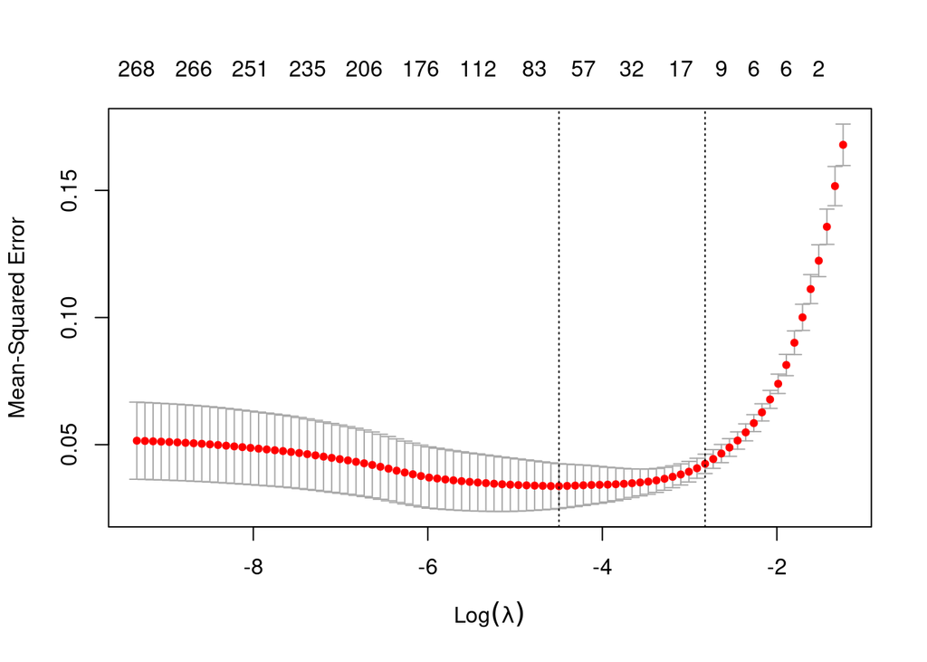

```r
plot(lasso)
```

Az optimális $log(\lambda)$ valahol -4 és -2 között van, ezt meg tudjuk nézni a modellből is:

```r
log(lasso$lambda.1se)
```

```
## [1] -2.822522
```

```r
lasso$lambda.1se
```

```
## [1] 0.0594558
```

A jobb értelmezhetőség érdekében a koefficienseket $e$-re emeljük, így azt kapjuk meg, hogy az adott magyarázó változó egy egységnyi növekedése(vagy kategorikus változó esetében ha abba a kaegóriába esik), akkor ceteris paribus hányszorosára fog nőni az eredményváltozó, azaz a lakásár.

```r
exp(coef(lasso, lambda = lasso$lambda.1se))
```

```
## 304 x 1 Matrix of class "dgeMatrix"
##                               s1
## (Intercept)           77.8211785
## MSSubClass_30          1.0000000
## MSSubClass_40          1.0000000
## MSSubClass_45          1.0000000
## MSSubClass_50          1.0000000
## MSSubClass_60          1.0000000
## MSSubClass_70          1.0000000
## MSSubClass_75          1.0000000
## MSSubClass_80          1.0000000
## MSSubClass_85          1.0000000
## MSSubClass_90          1.0000000
## MSSubClass_120         1.0000000
## MSSubClass_160         1.0000000
## MSSubClass_180         1.0000000
## MSSubClass_190         1.0000000
## MSZoning_FV            1.0000000
## MSZoning_RH            1.0000000
## MSZoning_RL            1.0000000
## MSZoning_RM            1.0000000
## Street_Pave            1.0000000
## Alley_Grvl             1.0000000
## Alley_Pave             1.0000000
## LotShape_IR2           1.0000000
## LotShape_IR3           1.0000000
## LotShape_Reg           1.0000000
## LandContour_HLS        1.0000000
## LandContour_Low        1.0000000
## LandContour_Lvl        1.0000000
## Utilities_NoSeWa       1.0000000
## LotConfig_CulDSac      1.0000000
## LotConfig_FR2          1.0000000
## LotConfig_FR3          1.0000000
## LotConfig_Inside       1.0000000
## LandSlope_Mod          1.0000000
## LandSlope_Sev          1.0000000
## Neighborhood_Blueste   1.0000000
## Neighborhood_BrDale    1.0000000
## Neighborhood_BrkSide   1.0000000
```

[output cut: 251 more lines]

```
## HalfBath               1.0000000
## BedroomAbvGr           1.0000000
## KitchenAbvGr           1.0000000
## TotRmsAbvGrd           1.0000000
## Fireplaces             1.0338724
## GarageYrBlt            1.0000000
## GarageCars             1.1105492
## GarageArea             1.0000042
## WoodDeckSF             1.0000000
## OpenPorchSF            1.0000000
## EnclosedPorch          1.0000000
## X3SsnPorch             1.0000000
## ScreenPorch            1.0000000
## PoolArea               1.0000000
## MiscVal                1.0000000
```

Mivel nagyon sok változónk van, ezért nem tudjuk mindegyiket értelmezni. Ezzel a $\lambda$ paraméterrel azonban a legtöbb változó $e$-re emelt értéke egy, azaz nincsen hatása az eredményváltozóra. A maradék változók közül a legfontosabbakat (szerintünk) emelnénk ki.

Fontos változónak tartjuk a *YearBuilt* és *YearRemodAdd* változókat. Ezek a változók azt mutatják meg, hogy mikor épült a ház és mikor lett felújítva utoljára. Amennyiben nem lett felújítva, úgy az építési évet tartalmazza. Ceteris paribus ha egy ház egy évvel később épült, akkor 0,16%-kal többe kerül. Ez teljesen logikus, hiszen minél később épült, annál újabb a ház. Az utolsó felújítás dátuma is növeli az árat, mégpedig minden egyes év 0,19%-kal növeli az eladási árat. Érdemes figyelembe venni, hogy a ezek házak nagyrészt a 20. és 21. században épületk, így habár egy évnyi változás nem számít sokat, azonban egy 30 éves és egy új ház között már észrevehető különbségek vannak.

A *GrLivArea* nevű változó a föld feletti lakóépület alapterülete négyzetlábban(squarefeet), aminek szintén pozitív hatása van az árra. C.p. egy négyzetlábnyi alapterület-növekedés 0,02%-kal nő a ház ára. Ez szintén nem magas $\beta$, viszont itt is érdemes figyelembe venni, hogy egy négyzetláb körülbelül 0,093 négyzetméter.

Mivel USA-beli ingatlanokról lévén szó, a modellben a garázsba beférő autók száma és a kandallók száma is fontos változó. C.p. eggyel több férőhelyes garázs 11,05%-kal növeli a vételárat, míg eggyel több kandalló 3,39%-kal.

### MARS modell

A MARS modellünkben megengedjük, hogy két változó interakcióba léphessen egymással.

```r
set.seed(2023)

mars = earth(log(SalePrice) ~., train, degree = 2)
summary(mars)
```

```
## Call: earth(formula=log(SalePrice)~., data=train, degree=2)
##
##                                           coefficients
## (Intercept)                                 12.5544066
## Condition1Norm                               0.0437087
## OverallQual9                                 0.0925262
## OverallCond3                                -0.2985235
## OverallCond4                                -0.1250480
## BsmtQualEx                                   0.0582356
## BsmtCondFa                                  -0.0850609
## FunctionalTyp                                0.0847383
## h(35133-LotArea)                            -0.0000059
## h(2004-YearBuilt)                           -0.0031462
## h(YearBuilt-2004)                            0.0307025
## h(1518-BsmtFinSF1)                          -0.0000355
## h(2121-TotalBsmtSF)                         -0.0001502
## h(1939-GrLivArea)                           -0.0003742
## h(GrLivArea-1939)                            0.0002960
## h(1-GarageCars)                             -0.0978963
## h(GarageCars-1)                              0.1835766
## h(69-Id) * OverallCond4                     -0.0296723
## h(Id-69) * OverallCond4                     -0.0000995
## AlleyPave * h(2121-TotalBsmtSF)              0.0000813
## NeighborhoodCrawfor * h(2121-TotalBsmtSF)    0.0001178
## NeighborhoodEdwards * h(GrLivArea-1939)     -0.0005671
## NeighborhoodIDOTRR * h(1939-GrLivArea)      -0.0001245
## OverallQual8 * h(1939-GrLivArea)             0.0002205
## OverallQual10 * h(2004-YearBuilt)            0.0036072
## OverallCond5 * h(2004-YearBuilt)            -0.0021895
## OverallCond6 * h(2004-YearBuilt)            -0.0012862
## h(2004-YearBuilt) * Exterior1stBrkFace       0.0021487
## h(2004-YearBuilt) * PoolQCGd                 0.0097249
## h(2004-YearBuilt) * SaleConditionNormal      0.0010448
## BsmtCondPo * h(2121-TotalBsmtSF)            -0.0002559
## BsmtExposureGd * h(GarageCars-1)             0.0512254
## KitchenAbvGr * h(GarageCars-1)              -0.1327807
## h(1-GarageCars) * FenceGdWo                 -0.3086433
## h(6629-LotArea) * h(1518-BsmtFinSF1)         0.0000000
## h(2004-YearBuilt) * h(YearRemodAdd-1971)     0.0000324
## h(2004-YearBuilt) * h(X1stFlrSF-734)        -0.0000016
## h(2004-YearBuilt) * h(734-X1stFlrSF)        -0.0000080
## h(YearBuilt-2004) * h(474-GarageArea)       -0.0005587
## h(1518-BsmtFinSF1) * h(2-Fireplaces)        -0.0000376
##
## Selected 40 of 47 terms, and 33 of 303 predictors
## Termination condition: RSq changed by less than 0.001 at 47 terms
## Importance: GrLivArea, YearBuilt, TotalBsmtSF, NeighborhoodEdwards, ...
## Number of terms at each degree of interaction: 1 16 23
## GCV 0.01273352    RSS 13.60847    GRSq 0.9246122    RSq 0.9358537
```

Az értelmezéshez szintén $e$-re emeljük a koefficienseket.

```r
exp(mars$coefficients)
```

```
##                                         log(SalePrice)
## (Intercept)                               2.833410e+05
## h(GrLivArea-1939)                         1.000296e+00
## h(1939-GrLivArea)                         9.996259e-01
## h(YearBuilt-2004)                         1.031179e+00
## h(2004-YearBuilt)                         9.968587e-01
## h(2121-TotalBsmtSF)                       9.998498e-01
## h(GarageCars-1)                           1.201507e+00
## h(1-GarageCars)                           9.067430e-01
## h(2004-YearBuilt)*h(YearRemodAdd-1971)    1.000032e+00
## h(1518-BsmtFinSF1)                        9.999645e-01
## KitchenAbvGr*h(GarageCars-1)              8.756571e-01
## NeighborhoodEdwards*h(GrLivArea-1939)     9.994331e-01
## NeighborhoodCrawfor*h(2121-TotalBsmtSF)   1.000118e+00
## OverallCond3                              7.419129e-01
## h(6629-LotArea)*h(1518-BsmtFinSF1)        1.000000e+00
## OverallCond4                              8.824545e-01
## OverallCond5*h(2004-YearBuilt)            9.978129e-01
## BsmtExposureGd*h(GarageCars-1)            1.052560e+00
## FunctionalTyp                             1.088432e+00
## h(1518-BsmtFinSF1)*h(2-Fireplaces)        9.999624e-01
## h(Id-69)*OverallCond4                     9.999005e-01
## h(69-Id)*OverallCond4                     9.707636e-01
## OverallCond6*h(2004-YearBuilt)            9.987146e-01
## h(2004-YearBuilt)*SaleConditionNormal     1.001045e+00
## BsmtQualEx                                1.059965e+00
## OverallQual8*h(1939-GrLivArea)            1.000221e+00
## h(1-GarageCars)*FenceGdWo                 7.344427e-01
## h(YearBuilt-2004)*h(474-GarageArea)       9.994415e-01
## h(2004-YearBuilt)*Exterior1stBrkFace      1.002151e+00
## NeighborhoodIDOTRR*h(1939-GrLivArea)      9.998755e-01
## AlleyPave*h(2121-TotalBsmtSF)             1.000081e+00
## BsmtCondFa                                9.184563e-01
## h(2004-YearBuilt)*h(X1stFlrSF-734)        9.999984e-01
## h(2004-YearBuilt)*h(734-X1stFlrSF)        9.999920e-01
## h(35133-LotArea)                          9.999941e-01
## OverallQual10*h(2004-YearBuilt)           1.003614e+00
## Condition1Norm                            1.044678e+00
## h(2004-YearBuilt)*PoolQCGd                1.009772e+00
## OverallQual9                              1.096942e+00
## BsmtCondPo*h(2121-TotalBsmtSF)            9.997441e-01
```

A MARS modellünkben is rengeteg változó és interakció van.

A tengelymetszet 236 217,7$, vagyis amennyiben minden változó nulla, akkor ennyibe kerül egy ingatlan.

Ez esetben is megjelentek a LASSO modellben is tárgyalt változók, azonban több változónak is lett zsanér(hinge) függvénye. Ismét nem szeretnénk végigmenni minden változón egyenként, viszont az előző modellből kiemelteken biztosan és még pár, a modell által fontosabbnak tartotton igen.

Állítottunk be seed-et, viszont így is két futtatás között megváltoztak az együtthatók és egyes esetekben a kiválasztott változók is, így itt van az az $e$-re emelt output, amit értelmeztünk:

```
                                    log(SalePrice)
```

(Intercept) 236217.6616888

h(GrLivArea-1939) 1.0003014

h(1939-GrLivArea) 0.9996407

h(YearBuilt-2004) 1.0313010

h(2004-YearBuilt) 0.9968511

h(2121-TotalBsmtSF) 0.9998704

h(GarageCars-1) 1.2394954

h(1-GarageCars) 0.6739098

h(2004-YearBuilt)*h(YearRemodAdd-1971) 1.0000298

h(1518-BsmtFinSF1) 0.9999662

KitchenAbvGr*h(GarageCars-1) 0.8617491

NeighborhoodEdwards*h(GrLivArea-1939) 0.9994623

NeighborhoodCrawfor*h(2121-TotalBsmtSF) 1.0001111

OverallCond3 0.7491963

h(LotArea-6629)*h(1518-BsmtFinSF1) 1.0000000

h(6629-LotArea)*h(1518-BsmtFinSF1) 1.0000000

OverallCond4 0.8199222

OverallCond5*h(2004-YearBuilt) 0.9978845

BsmtExposureGd*h(GarageCars-1) 1.0524385

FunctionalTyp 1.0882471

h(1518-BsmtFinSF1)*h(2-Fireplaces) 0.9999664

OverallCond4*RoofStyleGambrel 0.3594918

OverallCond6*h(2004-YearBuilt) 0.9988094

h(2004-YearBuilt)*SaleConditionNormal 1.0007675

OverallCond3*GarageYrBlt1958 0.5762609

BsmtQualEx 1.0644363

OverallQual8*h(1939-GrLivArea) 1.0001904

h(2004-YearBuilt)*Exterior1stBrkFace 1.0019601

h(1-GarageCars)*FenceGdWo 0.6573255

h(YearBuilt-2004)*h(474-GarageArea) 0.9994175

GarageYrBlt1952*h(GarageCars-1) 0.5120004

ExterQualTA*h(1-GarageCars) 1.3567470

ExterQualTA 0.9576057

MSZoningRM 0.9374751

NeighborhoodBrkSide*h(2004-YearBuilt) 1.0011472

Condition1Norm 1.0477374

OverallQual10*h(2004-YearBuilt) 1.0034633

OverallQual9 1.0962911

h(BsmtFullBath-1)*h(GarageCars-1) 1.0947250

h(1-BsmtFullBath)*h(GarageCars-1) 0.9780025

```
##  plotmo grid:    Id MSSubClass MSZoning LotFrontage LotArea Street Alley
##                 720         20       RL          64    9500   Pave     0
##  LotShape LandContour Utilities LotConfig LandSlope Neighborhood Condition1
##       Reg         Lvl    AllPub    Inside       Gtl        NAmes       Norm
##  Condition2 BldgType HouseStyle OverallQual OverallCond YearBuilt YearRemodAdd
##        Norm     1Fam     1Story           5           5      1974         1995
##  RoofStyle RoofMatl Exterior1st Exterior2nd MasVnrType MasVnrArea ExterQual
##      Gable  CompShg     VinylSd     VinylSd       None          0        TA
##  ExterCond Foundation BsmtQual BsmtCond BsmtExposure BsmtFinType1 BsmtFinSF1
##         TA      PConc       TA       TA           No          GLQ        384
##  BsmtFinType2 BsmtFinSF2 BsmtUnfSF TotalBsmtSF Heating HeatingQC CentralAir
##           Unf          0       476        1008    GasA        Ex          Y
##  Electrical X1stFlrSF X2ndFlrSF LowQualFinSF GrLivArea BsmtFullBath
##       SBrkr      1104         0            0      1458            0
##  BsmtHalfBath FullBath HalfBath BedroomAbvGr KitchenAbvGr KitchenQual
##             0        2        0            3            1          TA
##  TotRmsAbvGrd Functional Fireplaces FireplaceQu GarageType GarageYrBlt
##             6        Typ          1           0     Attchd        1978
##  GarageFinish GarageCars GarageArea GarageQual GarageCond PavedDrive WoodDeckSF
##           Unf          2        480         TA         TA          Y          0
##  OpenPorchSF EnclosedPorch X3SsnPorch ScreenPorch PoolArea PoolQC Fence
##           25             0          0           0        0      0     0
##  MiscFeature MiscVal MoSold YrSold SaleType SaleCondition
##            0       0      6   2009       WD        Normal
```

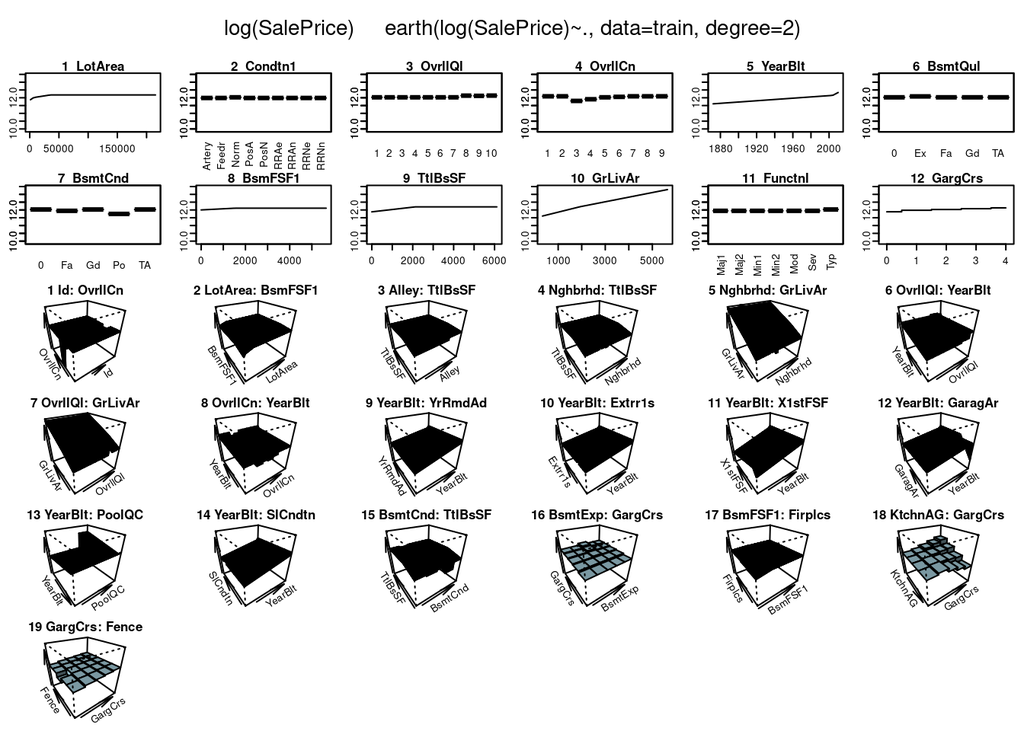

```r
plotmo(mars, ngrid2 = 308)
```

## Modellek összahasonlítása

Először is a teszt adatokon becsülünk a modellekkel

```r
x = cbind(df[-81], sample)
x = as.matrix(dummy_cols(x, remove_first_dummy = T, remove_selected_columns = T))
x = x[x[,"sample"] == 0,-ncol(x)]


test$lasso_pred = exp(predict(lasso, x, s = lasso$lambda.1se))

test$mars_pred = exp(predict(mars, test))
```

Ez a LASSO esetében:

```r
sqrt(sum((test$lasso_pred-test$SalePrice)^2))
```

```
## [1] 2389657
```

A MARS esetében pedig:

```r
sqrt(sum((test$mars_pred-test$SalePrice)^2))
```

```
## [1] 306992.8
```

A MARS modell jobban szerepelt, az RMSE-je töredéke a LASSO RMSE-jének.